# Bella beat analysis

Kelani

2022-09-02

# Bella beat fitness app analysis

## Scenario

You are a junior data analyst working on the marketing analyst team at Bellabeat, a high-tech manufacturer of health-focused products for women. Bellabeat is a successful small company, but they have the potential to become a larger player in the global market. Urška Sršen, cofounder and Chief Creative Officer of Bellabeat, believes that analyzing smart device fitness data could help unlock new growth opportunities for the company. You have been asked to focus on one of Bellabeat’s products and analyze smart device data to gain insight into how consumers are using their smart devices. The insights you discover will then help guide marketing strategy for the company. You will present your analysis to the Bellabeat executive team along with your high-level recommendations for Bellabeat’s marketing strategy

```r
  library(tidyverse)
  library(skimr)
  library(janitor)
```

Start by importing all necessary data for analysis coming from an african country I notice that the date are in *MM/DD/YYYY* so i decided to transform the date to *DD/MM/YYYY* using excel and then I decided to import the *dailyActivity_merged.csv*, *hourlyCalories_merged.csv*, *hourlyIntensities_merged.csv*, *hourlySteps_merged.csv*, *sleepDay_merged.csv*,*weightLoginfo_merged.csv* why I chose these data is because they are the reason people love to purchase their smart devices. let’s start by renaming each dataset

```r
daily_activity <- read_csv("E:/Fitabase Data/dailyActivity_merged.csv")
hourly_calories <- read_csv("E:/Fitabase Data/hourlyCalories_merged.csv")
hourly_intensities <- read_csv("E:/Fitabase Data/hourlyIntensities_merged.csv")
hourly_steps <- read_csv("E:/Fitabase Data/hourlySteps_merged.csv")
sleep_day <- read_csv("E:/Fitabase Data/sleepDay_merged.csv")
weight_log <- read_csv("E:/Fitabase Data/weightLoginfo_merged.csv")
```

```
## ──────────────────────────────────────────────────────── Delimiter: "," chr
## (2): Date...2, Date...9 dbl (6): Id, WeightKg, WeightPounds, Fat, BMI, LogId
```

Checking the number of partipant in each data set Id

```r
n_distinct(daily_activity$Id)
```

```
## [1] 33
```

```r
n_distinct(hourly_calories$Id)
```

```
## [1] 33
```

```r
n_distinct(hourly_intensities$Id)
```

```
## [1] 33
```

```r
n_distinct(hourly_steps$Id)
```

```
## [1] 33
```

```r
n_distinct(sleep_day$Id)
```

```
## [1] 24
```

```r
n_distinct(weight_log$Id)
```

```
## [1] 8
```

I got the total number of each participants in the datasets daily_activities 33, hourly_calories 33, hourly_intensities 33, hourly_steps 33, sleep_day 24 and weigth_log 8 it goes without saying that 8 participants is not a proper sample size.

```r
daily_activity %>%
  summarise(avg_total_steps =mean(TotalSteps),
            avg_calories = mean(Calories),
            avg_Total_distance = mean(TotalDistance),
            avg_sedentaryMinutes = mean(SedentaryMinutes))
```

| avg_total_steps | avg_calories | avg_Total_distance | avg_sedentaryMinutes |
| --- | --- | --- | --- |
| 7637.911 | 2303.61 | 5.489702 | 991.2106 |

```r
# taking average time people sleep per day and average time people stay_in bed
sleep_day %>% summarise(avg_TotaltimeInBed = mean(TotalTimeInBed),
                        avg_Totaltimeasleep = mean(TotalMinutesAsleep))
```

| avg_TotaltimeInBed | avg_Totaltimeasleep |
| --- | --- |
| 458.6392 | 419.4673 |

```r
hourly_steps %>% summarise(avg_totalsteps = mean(StepTotal))
```

| avg_totalsteps |
| --- |
| 320.1663 |

```r
weight_log %>%
  summarise(avg_weight_kg = mean(WeightKg),
            avg_BMi = mean(BMI),
            avg_fat = mean(Fat, na.rm=TRUE))
```

| avg_weight_kg | avg_BMi | avg_fat |
| --- | --- | --- |
| 72.03582 | 25.18522 | 23.5 |

# visualization

I think it is now time to visualize our data

let’s start by merging our data

```r
merged_data <-  merge(daily_activity, sleep_day, by=c('Id'))
```

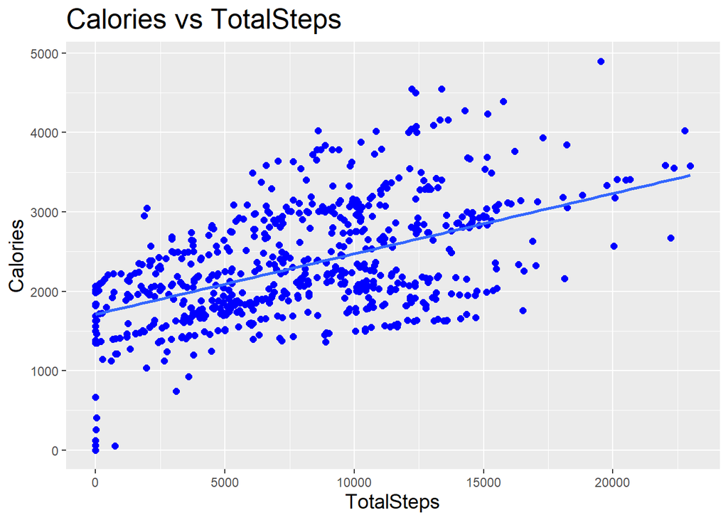

```r
ggplot(data = merged_data, aes(x=TotalSteps, y=Calories)) +
  geom_point(color = "Blue", size= 2) +
  geom_smooth(method = lm, se = FALSE) +
  labs(title = "Calories vs TotalSteps",)+
  theme(axis.title.y = element_text(size = 14),
        axis.title.x = element_text(size = 14),
        title = element_text(size = 16))
```

Here we could see a positive relationship between walking and calories which means the more you walk the more calories you burn

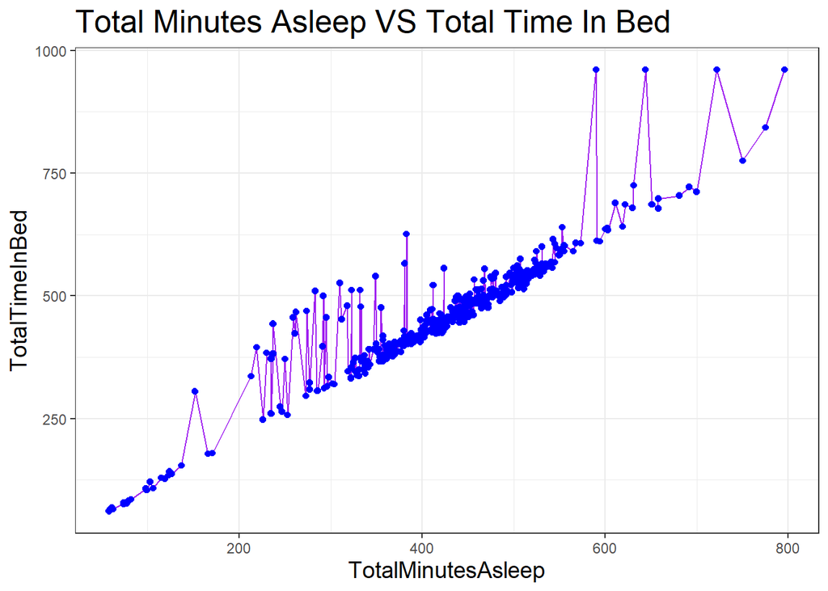

```r
ggplot(data = merged_data, aes(x=TotalMinutesAsleep, y= TotalTimeInBed)) +
  geom_line(color = "purple")+
  geom_jitter(color = "Blue")+
  labs(title = "Total Minutes Asleep VS Total Time In Bed")+
  theme_bw()+
  theme(axis.title.x = element_text(size = 14),
        axis.title.y = element_text(size = 14),
        title = element_text(size= 16))
```

There’s a linear trend in the total time spent sleeping compared to the total time spent on Bed this is to show that Bella beat can help it customer by notifying them on when to sleep and advising customers to sleep an average of 7 hours a day

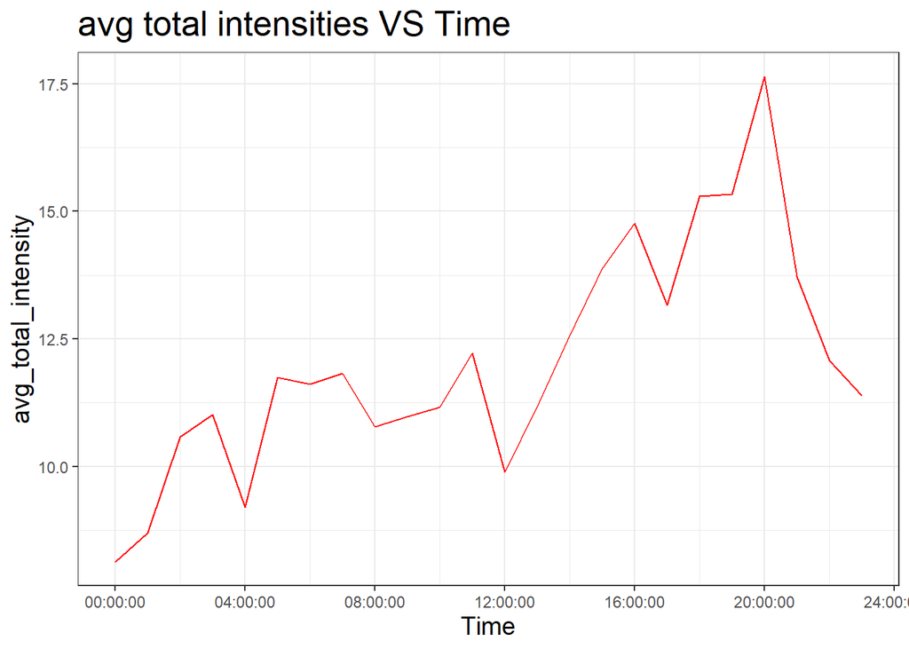

```r
avg_hourly_intensities <- hourly_intensities %>%
  group_by(Time) %>%
  summarise(avg_total_intensity = mean(TotalIntensity))

ggplot(data = avg_hourly_intensities, aes(x= Time, y=avg_total_intensity)) +
  geom_line( color= "Red") +
  theme_bw()+
  labs(title = "avg total intensities VS Time")+
  theme(axis.title.x = element_text(size = 14),
        axis.title.y = element_text(size = 14),
        title = element_text(size= 16))
```

Here we see that people seems to be more active in the afternoon the graph shows us that from 12pm to 8 pm is when people become more intense which means they just have their office lunch time or are just coming back from work and wants to visit the gym aroound this time they could be notified to do some sort of fitness exercise to help them loose fatigue

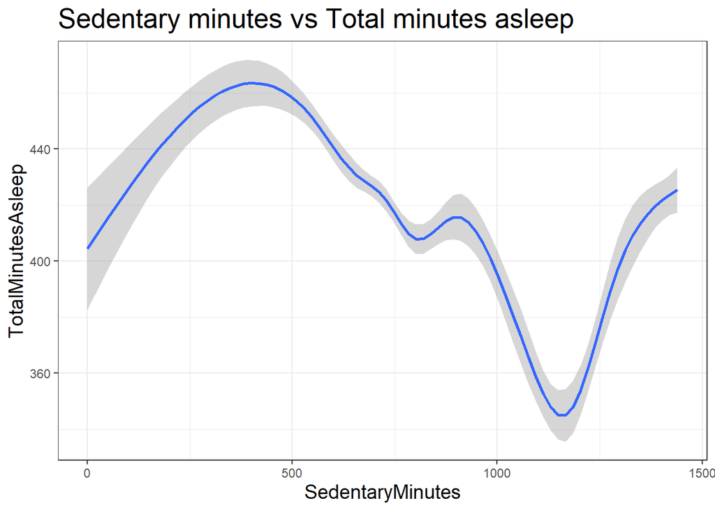

```r
ggplot(merged_data, aes(x=SedentaryMinutes, y= TotalMinutesAsleep)) +
  geom_smooth()+
  labs(title = "Sedentary minutes vs Total minutes asleep")+
  theme_bw()+
  theme(axis.title.x = element_text(size = 14),
        axis.title.y = element_text(size = 14),
        title = element_text(size= 16))
```

This are the insight that I was able to draw from the analysis * and also not to make mistake that correlation does not lead to causation*

# Conslusion

In conclusion after analyzing the data I think that I have been able to Identify pattern that can help Bella beat in their marketing strategy